# Ocena ryzyka rynkowego

Aleksandra Węgrzyn

2025-01-20

## 1. Wprowadzenie

W ramach niniejszego projektu przeprowadzono analizę ryzyka rynkowego dla trzech spółek świadczących usługi bankowe: PKO, mBank oraz Millenium. Dane wykorzystane w badaniu obejmują dzienne ceny akcji spółek w okresie od 2 stycznia 2007 roku do 28 listopada 2024 roku. Celem analizy jest wyznaczenie indeksów ryzyka Var oraz ES za pomocą różnych metod oraz oszacowanie ich skuteczności.

## 2. Wstępna analiza danych

Przed przystąpieniem do głównej części projektu dokonano wizualizacji dziennych cen akcji badanych spółek w celu wstępnej analizy dynamiki ich zmian oraz identyfikacji potencjalnych trendów.

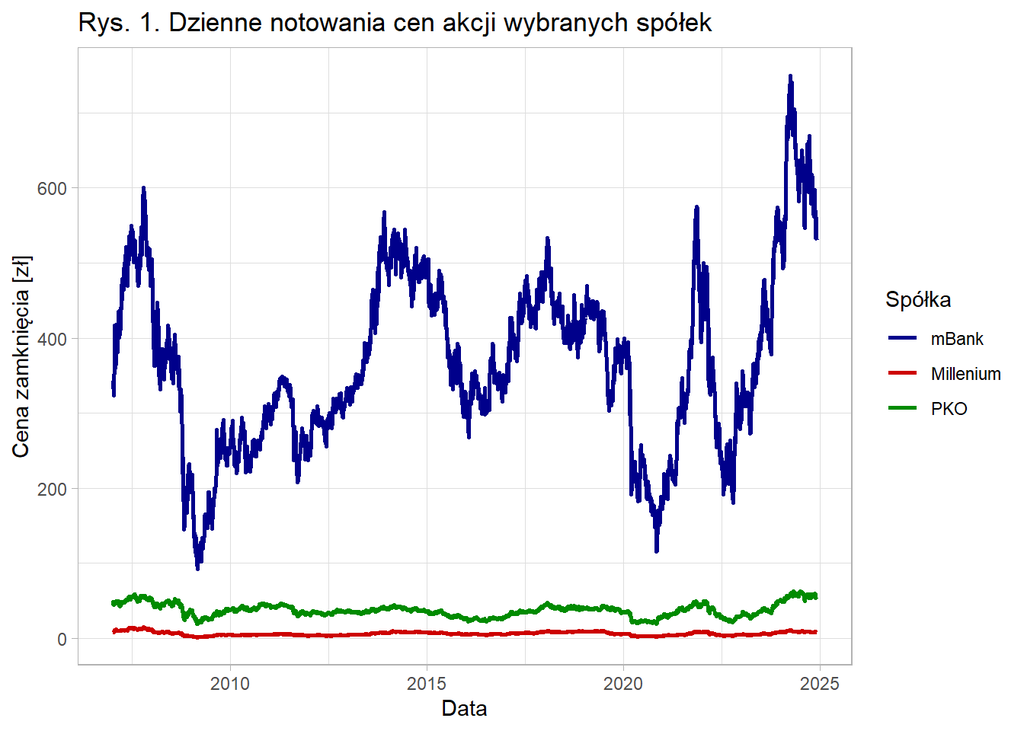

Na podstawie powyższej wizualizacji dziennych cen akcji można zaobserwować wyraźnie wyższe wartości cen w przypadku akcji mBanku w porównaniu do pozostałych spółek w analizowanym okresie. W poszczególnych okresach zauważalne jest również występowanie znacznych wahań, które są charakterystyczne dla dynamiki zmian na rynkach finansowych.

Chcąc dokonać dokładniejszej analizy dziennych cen akcji analizowanych spółek obliczono podstawowe statystyki opisowe, które zostały przedstawione w poniższej tabeli.

Tabela 1. Statystyki opisowe cen akcji wybranych spółek

| Statystyka | mBank | PKO | Millennium |
| --- | --- | --- | --- |
| Średnia | 367.688 | 37.407 | 6.317 |
| Mediana | 358.000 | 37.000 | 5.850 |
| Minimum | 92.699 | 18.900 | 1.360 |
| Maksimum | 750.000 | 62.920 | 14.600 |
| Skośność | 0.272 | 0.385 | 0.580 |
| Odchylenie standardowe | 117.889 | 8.735 | 2.401 |

W celu przeprowadzenia analizy ryzyka dla analizowanych spółek niezbędne jest obliczenie logarytmicznych stóp zwrotu. Logarytmiczne stopy zwrotu są powszechnie wykorzystywane w analizach finansowych ze względu na umożliwienie łatwiejszego porównania wyników różnych inwestycji oraz ich interpretację.

Poniżej zaprezentowano wizualizację logarytmicznych stóp zwrotu, która ilustruje ich zmienność w badanym okresie. Ponadto wyznaczono podstawowe statystyki opisowe dla tych stóp zwrotu.

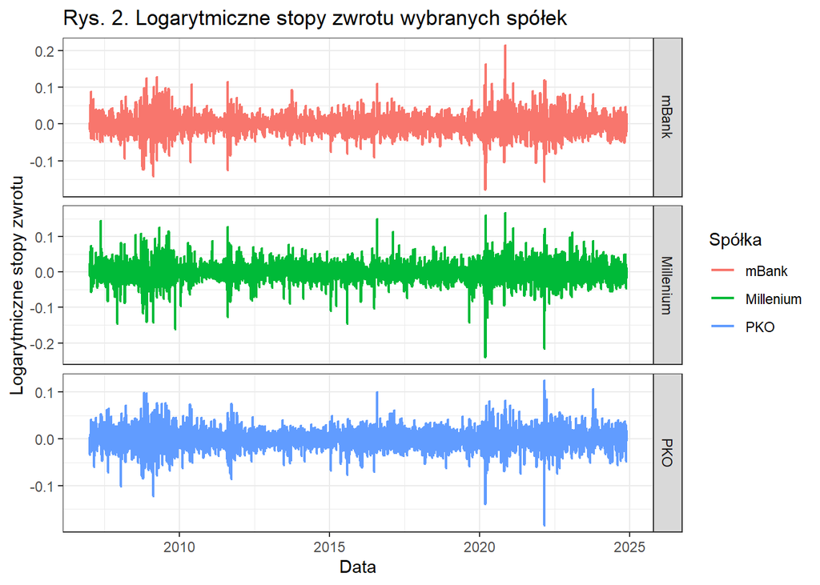

Powyższe wykresy wskazują na wystepowanie istotnych zmian w wariancji w poszczególnych okresach. Szczególnie zauważalna zmiana miała miejsce w 2022 roku, co było konsekwencją wybuchu wojny między Rosją i Ukrainą. Znaczącą zmianę wariancji zaobserwowano również po 2020 roku, co można powiązać z okresem pandemii COVID-19 mającej znaczący wpływ na rynek finansowy. Podobnie, w latach 2008-2009 wariancja uległa wyraźnym zmianom będącym konsekwencją globalnego kryzysu finansowego. Kryzys ten, który rozpoczął się od załamania rynku nieruchomości w Stanach Zjednoczonych, doprowadził do znacznych fluktuacji cen akcji oraz zwiększonej zmienności na rynkach kapitałowych.

W tabeli poniższej dokonano zestawienia podstawowych statystyk opisowych dla logarytmicznych stóp zwrotu.

Tabela 2. Statystyki opisowe logarytmicznych stóp zwrotu

[output not shown]

W analizie rynków finansowych jednym z założeń jest normalność rozkładu stóp zwrotu. Należy jednak zauważyć, że w praktyce to założenie rzadko jest spełnione. W celu weryfikacji normalności rozkładu stóp zwrotu porównano empiryczne oraz teoretyczne częstości występowania wartości stóp zwrotu w określonych przedziałach. Wyniki dla spółki Millenium zamieszczono w tabeli poniżej.

Tabela 3. Porównanie empirycznej i teoretycznej częstości stóp zwrotu

| zmiana | historia (%) | rozkład normalny (%) |
| --- | --- | --- |
| < 1 SD | 75.99 | 68.27 |
| 1-2 SD | 19.24 | 27.18 |
| 2-3 SD | 3.37 | 4.28 |
| 3-4 SD | 0.89 | 0.26 |
| 4-5 SD | 0.25 | 0.01 |
| > 5 SD | 0.27 | 0.00 |

Analizując przedstawione dane dotyczące empirycznej i teoretycznej częstości można zauważyć, że rozkład empiryczny stóp zwrotu znacznie odbiega od rozkładu normalnego. Skrajne wartości, większe niż trzykrotność odchylenia standardowego, występują częściej w danych niż przewiduje to rozkład normalny, co wskazuje na obecność grubych ogonów w rozkładzie stóp zwrotu.

## 3. Wyznaczenie miar ryzyka rynkowego

W celu oceny ryzyka rynkowego wyznaczone zostaną dwie kluczowe miary ryzyka: **Value at Risk (VaR)** oraz **Expected Shortfall (ES)**. Miary te zostaną wyznaczone z wykorzystaniem czterech różnych metod: metody historycznej, metody historycznej z wagami, metody z wykorzystaniem modelu EWMA oraz metody symulacji Monte Carlo. Badanie zostało przeprowadzone dla 500-dniowego okna danych historycznych.

```r
# Przygotowanie danych
mil_d$date <- as.Date(mil_d$Data, format = "%Y-%m-%d")
mil_d$prices <- as.numeric(mil_d$Zamkniecie)
mil_d$log_returns <- c(NA, diff(log(mil_d$Zamkniecie)))
mil_d$losses <- -c(NA, diff(log(mil_d$Zamkniecie)))
mil_data <- mil_d[, c("date", "prices", "log_returns", "losses")]
```

### 3.1. Metoda historyczna

**Metoda symulacji historycznej** stanowi jedną z najprostszych technik obliczania wartości zagrożonej. Wykorzystuje ona dane historyczne dotyczące analizowanego instrumentu finansowego, które pozwalają na określenie empirycznego rozkładu stóp zwrotu. Na tej podstawie możliwe jest wyznaczenie wartości narażonej na ryzyko poprzez obliczenie odpowiedniego kwantyla tego rozkładu. W metodzie tej zakłada się, że wszystkie obserwacje mają równe prawdopodobieństwo wystąpienia, co sprawia, że każdy scenariusz jest traktowany jako równie prawdopodobny w kontekście przyszłych zmian wartości aktywów.

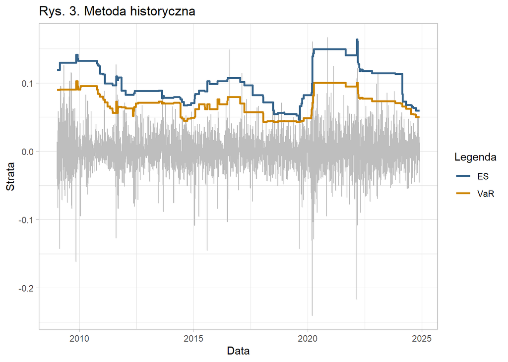

```r
# Metoda symulacji historycznej
HS_method <- function(data, window_size) {

  VaR <- rep(NA, nrow(data))
  ES <- rep(NA, nrow(data))

  for (i in (window_size + 1):nrow(data)) {

    window_data <- data[(i - window_size):(i - 1), "losses"]

    VaR[i] <- quantile(window_data, 0.99)
    ES[i] <- mean(window_data[window_data > VaR[i]])
  }

  data$VaR <- VaR
  data$ES <- ES

  return(data)
}

HS_results <- HS_method(mil_data[-1,], 500)
```

Na podstawie powyższej wizualizacji przedstawiającej wartości Var i ES obliczone przy zastosowaniu metody symulacji historycznej z 500-dniowym oknem obserwacji można stwierdzić, że w analizowanym okresie wielkości wartości zagrożonej mieściły się w przedziale od 4.27% do 10.23%. Większość rzeczywistych strat znajdowała się poniżej wyznaczonego poziomu VaR. Niemniej jednak, w okresach występowania wysokiej zmienności rynkowej, takich jak w 2020 roku, wartość VaR była kilkukrotnie przekraczana. Zgodnie z teorią ryzyka, wartości ES tj. warunkowej wartości wartości narażonej na ryzyko były wyższe od odpowiadających im wartości VaR. Wynika to z faktu, że ES uwzględnia średnią stratę w przypadku strat przekraczających ustalony próg wartości zagrożonej.

### 3.2. Metoda historyczna z wagami

**Metoda symulacji historycznej z wagami** polega na przypisaniu większej wagi bardziej aktualnym obserwacjom, co pozwala na lepsze odwzorowanie obecnych warunków makroekonomicznych oraz zmienność waloru. W przeciwieństwie do klasycznej symulacji historycznej, w której realizacja każdego scenariusza jest tak samo prawdopodobna, w tym przypadku wagi przypisywane do poszczególnych obserwacji maleją w sposób wykładniczy.

Wagi dla scenariuszy wynaczane są według wzoru:

$$p_i=\frac{q^{n-i} \cdot(1-q)}{1-q^n}$$
gdzie: $\small n$ jest liczbą rozważanych scenariuszy, a $\small q ∈ (0,1)$ oznacza współczynnik wygładzania i najczęściej przyjmuje wartości bardzo bliskie 1.

W wyniku tego procesu, najnowsze dane mają większy wpływ na końcowy wynik, co umozliwialepsze odwzorowanie zmienności i ryzyka w danym momencie. W obliczeniach przyjęto: $\small q$ = 0.995 oraz 500-dniowe okno danych historycznych.

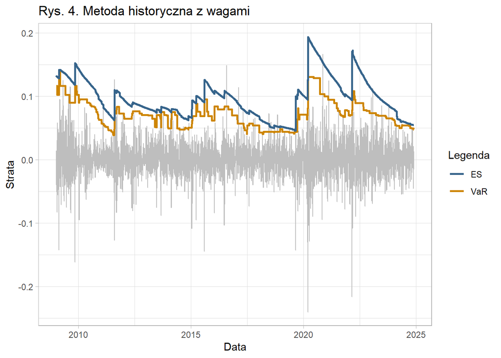

```r
# Metoda symulacji historycznej z wagami
 WHS_method <- function(data, window_size, q) {

   weighted_VaR <- rep(NA, nrow(data))
   weighted_ES <- rep(NA, nrow(data))

   probs <- c(q ^ (window_size - 1:window_size) * (1 - q) / (1 - q ^ window_size))

   for (i in (window_size + 1):nrow(data)) {

     window_data <- data[(i - window_size):(i - 1), "losses"]

     results <- data.frame(
       losses = window_data,
       p = probs
     ) %>%
       arrange(losses) %>%
       mutate(p_cum = cumsum(p))

     exceedance <- results %>%
       filter(p_cum > 0.99)

     weighted_VaR[i] <- exceedance$losses[1]
     exceedance$p[1] <- 0.01 - sum(exceedance$p[-1])
     weighted_ES[i] <- sum(exceedance$losses * exceedance$p) / sum(exceedance$p)
   }

   data$weighted_VaR <- weighted_VaR
   data$weighted_ES <- weighted_ES

   return(data)
 }

 WHS_results <- WHS_method(mil_data[-1,], 500, 0.995)
```

Na podstawie analizy przedstawionej wizualizacji można z całą pewnością stwierdzić, że wprowadzenie wag w symulacji historycznej umożliwia bardziej adekwatne dostosowanie wartości zagrożonej do aktualnych warunków panujących na rynku. Należy zwrócić uwagę, że w okresach nastepujących po kryzysach finansowych zjawisko przeszacowania ryzyka jest mniej widoczne w porównaniu z tradycyjną metodą historyczną. W przypadku rozważanej metody wartości zagrożone mieszczą się w szerszym przedziale, który wynosi od 3.87% do 13.98%.

### 3.3. Metoda z zastosowaniem modelu EWMA

W tradycyjnych metodach obliczania VaR opartych na danych historycznych, istnieje ryzyko, że prognozowana zmienność nie odzwierciedla aktualnych warunków rynkowych. W celu rozwiązania tego problemu stosuje się metodę wykorzystującą **model EWMA (ang. Exponential Weighted Moving Average)**, w którym warunkowa wariancja estymowana jest jako wykładniczo ważona średnia jej wcześniejszych wartości. Wartość wariancji w danym okresie jest wyznaczana na podstawie wzoru:

$$\sigma_{i+1}^2={\lambda \cdot \sigma_i^2+(1-\lambda) \cdot u_i^2}$$

gdzie $\small \sigma_{i+1}^2$ oznacza szacowaną wariancję na dzień $\small i + 1$, $\small u_i$ jest logarytmiczną stopą zwrotu dla dnia $\small i$, a $\small λ$ to współczynnik wygładzania, który określa wagę przypisaną wcześniejszym danym, przyjmujący wartości w przedziale od 0 do 1.

Zmiana wartości w scenariuszach historycznych jest realizowana zgodnie z poniższym wzorem:

$$\operatorname{scenariusz}(i)=\operatorname{strata}(i) \cdot
\frac{\sigma_{n+1}}{\sigma_i}$$

```r
# Metoda EWMA
 EWMA_method <- function(data, window_size, lambda) {

   EWMA_VaR <- rep(NA, nrow(data))
   EWMA_ES <- rep(NA, nrow(data))

   sigma <- rep(NA, nrow(data))
   sigma[1] <- sd(data$losses, na.rm = TRUE)

   for (i in 2:nrow(data)) {
     sigma[i] <- sqrt(lambda * sigma[i - 1]^2 + (1 - lambda) * data$losses[i - 1]^2)
   }

   for (i in (window_size + 1):nrow(data)) {

     window_data <- data[(i - window_size):(i - 1), "losses"]

     adjusted_losses <- window_data * sigma[i] / sigma[(i - window_size):(i - 1)]

     EWMA_VaR[i] <- quantile(adjusted_losses, 0.99, na.rm = TRUE)
     EWMA_ES[i] <- mean(adjusted_losses[adjusted_losses > EWMA_VaR[i]], na.rm = TRUE)
   }

   data$EWMA_VaR <- EWMA_VaR
   data$EWMA_ES <- EWMA_ES

   return(data)
 }

 EWMA_results <- EWMA_method(mil_data[-1,], 500, 0.94)
```

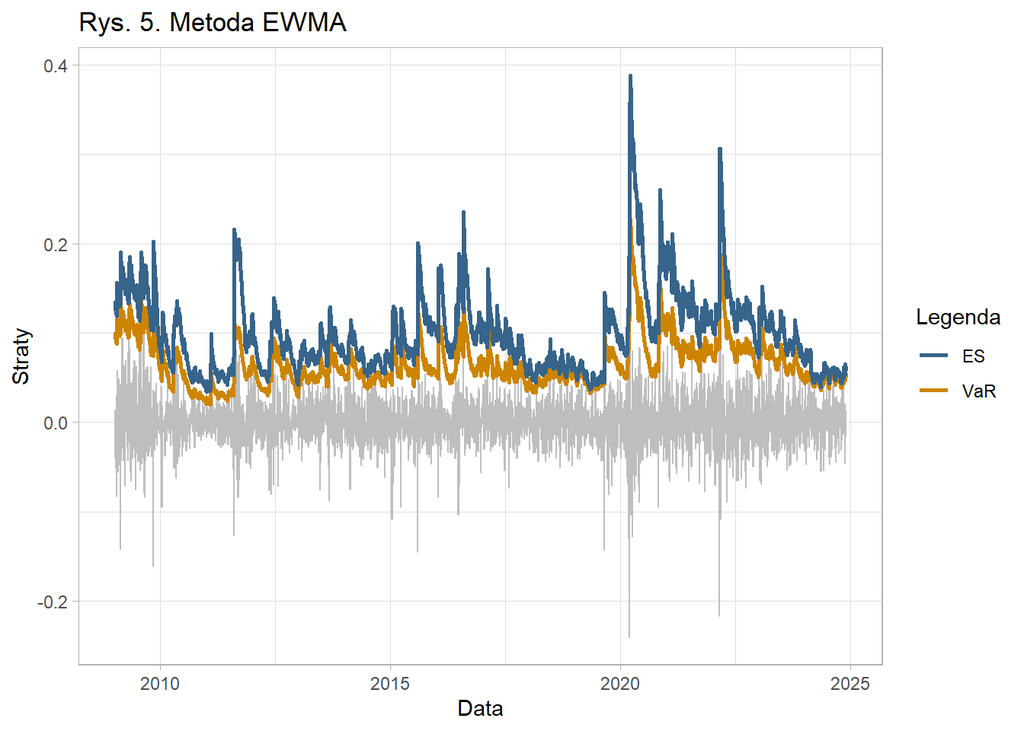

Miary ryzyka wyznaczone za pomocą modelu EWMA wykazują istotne różnice w porównaniu z rezultatami uzyskanymi przy zastosowaniu wcześniejszych metod. Analiza powyższej wizualizacji wskazuje na dynamiczną reakcję modelu na zmiany warunków rynkowych, co czyni go bardziej elastycznym w porównaniu do wcześniejszych podejść. Rzadko dochodzi do sytuacji, w których rzeczywista strata przekraczałaby wyestymowane wartości VaR i ES. Wykazują one silną zgodność z rzeczywistymi wynikami dla większości przypadków.

### 3.4. Metoda Monte Carlo

**Metoda symulacji Monte Carlo** jest szczególnie użyteczna w sytuacjach, w których dostęp do danych dotyczących zmian cen aktywów portfela jest ograniczony lub niewystarczający do przeprowadzenia analizy za pomocą tradycyjnej metody symulacji historycznej. Dzięki tej metodzie możliwe jest generowanie rozległych zestawów sztucznie stworzonych zdarzeń, które są następnie wykorzystywane do oszacowania wartości zagrożonej (VaR).

```r
# Metoda Monte Carlo
set.seed(123)

MC_method <- function(data, window_size) {

  MC_VaR <- rep(NA, nrow(data))
  MC_ES <- rep(NA, nrow(data))

  for (i in (window_size + 1):nrow(data)) {

    window_data <- data[(i - window_size):(i - 1), "log_returns"]

    mu <- mean(window_data)
    sigma <- sd(window_data)

    MC_distr <- rnorm(10000, mu, sigma)
    MC_losses <- -1 * MC_distr

    MC_VaR[i] <- quantile(MC_losses, 0.99)
    MC_ES[i] <- mean(MC_losses[MC_losses > MC_VaR[i]])
  }

  data$MC_VaR <- MC_VaR
  data$MC_ES <- MC_ES

  return(data)
}

MC_results <- MC_method(mil_data[-1,], 500)
```

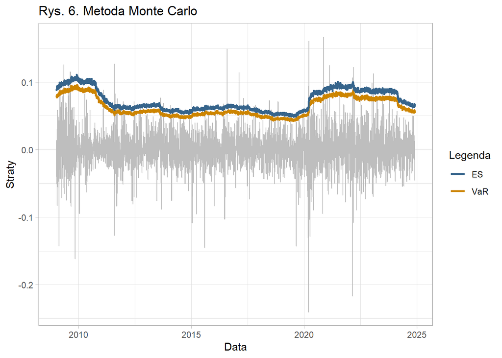

Analizując przedstawioną wizualizację można zauważyć, że wyniki uzyskane za pomocą metody symulacji Monte Carlo wskazują na stosunkowo dobre oszacowania wartości zagrożonej oraz niedoboru rynkowego. Estymowane miary ryzyka wykazują znaczną stabilność, utrzymując się przez dłuższy czas na względnie stałym poziomie. Choć taka cecha może być korzystna w warunkach umiarkowanej zmienności rynkowej, równocześnie wskazuje na ograniczoną zdolność tej metody do szybkiego reagowania na nagłe zmiany rynkowe, co jest widoczne na omawianej wizualizacji.

Zdecydowano się na porównanie wyników uzyskanych za pomocą metody symulacji Monte Carlo z rezulatami otrzymanymi przy wykorzystaniu klasycznej metody historycznej. Poniżej przdstawiono odpowiednie wizualizacje.

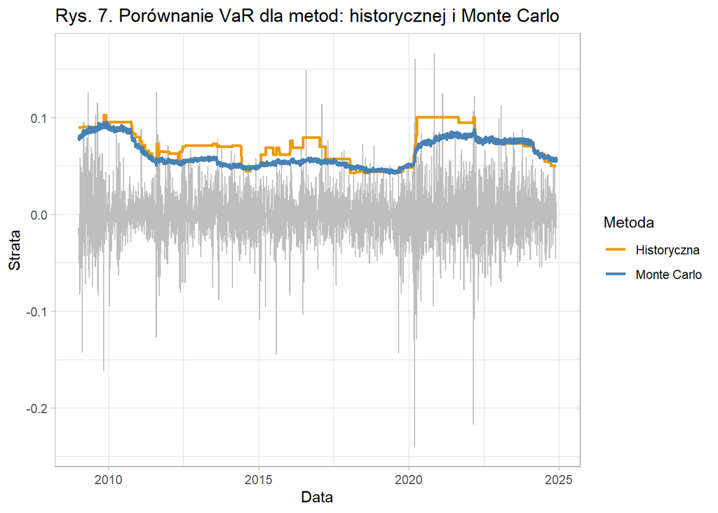

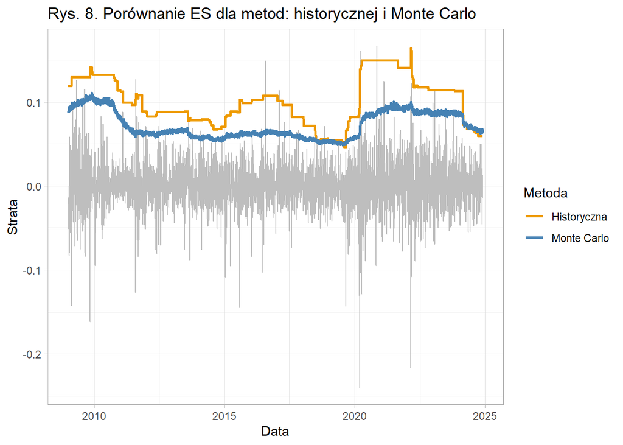

Na podstawie powyższych wizualizacji można stwierdzić, że metoda symulacji historycznej lepiej odzwierciedla rzeczywiste ryzyko w porównaniu do metody symulacji Monte Carlo, w której oszacowane miary ryzyka często bywają niedoszacowane. Wynika to z faktu, iż rzeczywisty rozkład stóp zwrotu charakteryzuje się tzw. “grubymi ogonami”, co oznacza większe prawdopodobieństwo wystąpienia skrajnych strat. W przeciwieństwie do tego, metoda Monte Carlo zazwyczaj opiera się na założeniu rozkładu normalnego, co prowadzi do uzyskania zaniżonych wyników.

## 4. Porównanie wyników

Na poniższych wizualizacjach przedstawiono wyestymowane wartości indeksów ryzyka, uzyskane przy zastosowaniu trzech metod: symulacji historycznej, symulacji historycznej z wagami oraz modelu EWMA. Dodatkowo, przeprowadzono porównanie wyników uzyskanych za pomocą tych metod dla trzech spółek z sektora bankowego: PKO Banku Polskiego, mBanku oraz Banku Millennium.

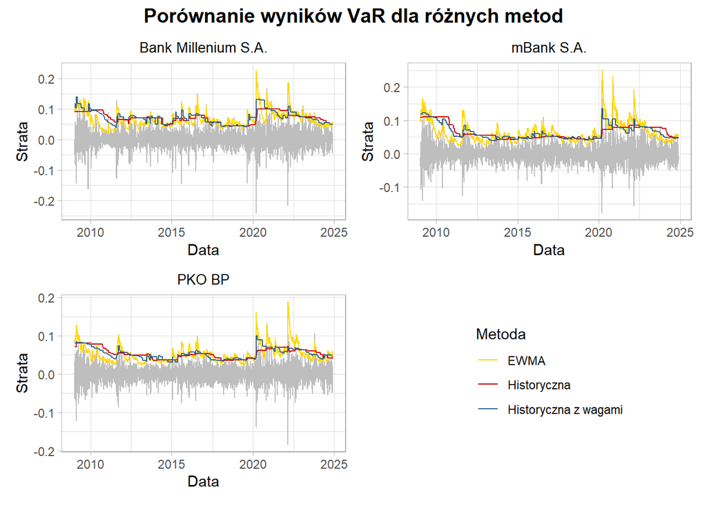

Analiza przedstawionych wizualizacji dotyczących metod szacowania wartości zagrożonej (VaR) wskazuje, iż najbardziej efektywnym podejściem wydaje się być metoda oparta na modelu EWMA, która charakteryzuje się wysoką wrażliwością na zmianność rynkową. W okresach wzmożonej niepewności VaR wyznaczony tą metodą osiąga najwyższe wartości, a następnie szybko spada wraz ze stabilizacją warunków rynkowych. Należy jednak zauważyć, że w okresach gwałtownych wahań rynkowych, takich jak w latach 2020–2021, metoda ta może prowadzić do przeszacowania wartości VaR, co zwiększa ryzyko podejmowania nieoptymalnych decyzji inwestycyjnych. Z kolei metoda historyczna, choć zapewnia stabilność estymacji, reaguje z opóźnieniem na zmiany rynkowe. Metoda historyczna z wagami stanowi rozwiązanie pośrednie w odniesieniu do dwóch omówionych wcześniej metod. Uwzględnienie wag umożliwia lepsze odwzorowanie aktualnych warunków rynkowych, jednak nie zapewnia pełnej odporności na nagłe zmiany na rynku.

W przypadku porównania wyników szacowania wartości zagrożonej wśród spółek bankowych, dostrzegalne są wyraźne podobieństwa w ich wzorcach zachowań. Dla każdego z analizowanych banków można zaobserwować trzy istotne wahania zmienności, które miały miejsce w latach 2020-2023. W szczególności, w przypadku mBanku, zaobserwowano największe skoki zmienności w latach 2020-2021, które szczególnie wyróżniają się na tle innych instytucji bankowych. Chociaż podobne zmiany występują także w innych rozważanych spółkach, to w przypadku mBanku miały one charakter bardziej skokowy i intensywniejszy.

Opisane zmienności mogą wynikać z kilku kluczowych wydarzeń makroekonomicznych. W latach 2020-2021 największe wahania związane były z wybuchem pandemii COVID-19 oraz jej drastycznym wpływem na gospodarki globalne, w tym na rynki finansowe. W tym okresie banki doświadczyły gwałtownego wzrostu niepewności, co miało bezpośredni wpływ na wartość zagrożoną. Natomiast w 2022 roku zaobserwowana zmienność mogła być efektem konfliktu zbrojnego na Ukrainie.

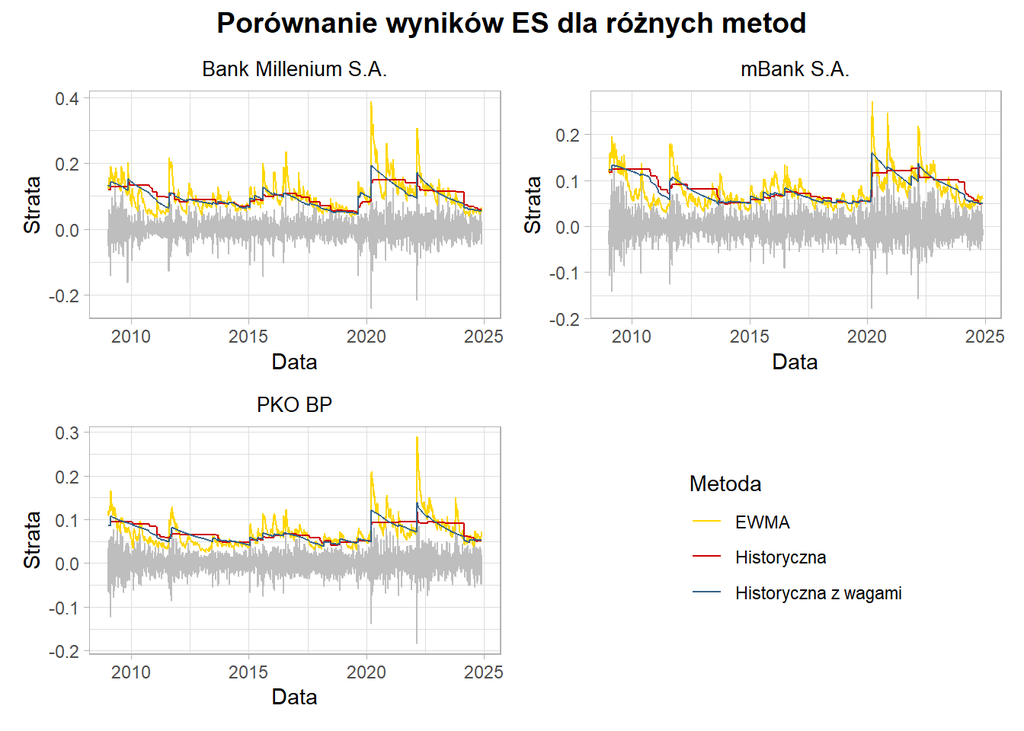

Analizujac powyższe wizualizacje można stwierdzić, że zastosowanie metod symulacji historycznej oraz symulacji historycznej uwzględniającej wagi do wyznaczenia warunkowej wartości narażonej na ryzyko (ES) pozwala na uzyskanie bardziej precyzyjnych oszacowań ryzyka dla spółek bankowych. Wspomniana miara ryzyka, w przeciwieństwie do VaR, który wskazuje jedynie maksymalną stratę przy danym poziomie ufności, mierzy średnią stratę w sytuacji, gdy straty przekraczają ten próg. Jesli chodzi o metodę wykorzystująca EWMA często prowadzi do zawyżania oszacowań ryzyka, szczególnie w okresach gwałtownych wahań zmienności.

## 5. Testy wsteczne

W celu oceny efektywności poszczególnych technik wyznaczania wartości narażonej na stratę pod względem oszacowania ryzyka, zdecydowano się na przeprowadzenie testów wstecznych. W ramach niniejszej pracy skoncentrowano się na dwóch testach pokrycia: teście Kupca oraz teście wykorzystującym rozkład dwumianowy, a także na teście niezależności Christoffersena. Testy przeprowadzono dla wyników uzyskanych przy zastosowaniu trzech metod estymacji VaR: symulacji historycznej z wagami, EWMA oraz symulacji Monte Carlo.

### 5.1. Test Kupca

**Test Kupca** jest jednym z powszechnie stosowanych narzędzi do oceny jakości oszacowania wartości narażonej na stratę (VaR). Jego celem jest weryfikacja, czy udział przekroczeń poziomu VaR odpowiada przyjętemu poziomowi istotności. Odrzucenie hipotezy zerowej wskazuje na niedoszacowanie lub przeszacowanie ryzyka przez zastosowany model. W ramach wspomnianego testu przyjmuje się następujący układ hipotez:

$$\begin{align*}
H_0: & \; \text{VaR } \text{ jest dobrze wyznaczony} \\
H_1: & \; \text{VaR } \text{ nie jest dobrze wyznaczony}
\end{align*}$$

```r
# Test Kupca
K_test <- function(data, var, window_size) {

  K_results <- data.frame(date = as.Date(character()), LR = numeric(),
                          num_exceptions = numeric())

  for(i in 1:(nrow(data) - window_size)){
     window <- data[i:(i + window_size - 1), ]

    losses <- -1 * window$log_returns

    n <- window_size
    if (!is.na(var[i])) {
      m <- sum(losses > var[i])
      p <- 0.01

      lr <- -2*log((1 - p)^(n - m) * p^m) + 2*log((1 - m/n)^(n - m) * (m/n)^m)

      window_date <- data$date[i + window_size - 1]
      K_results <- rbind(K_results, data.frame(date = window_date, LR = lr, num_exceptions = m))
    }
  }

  return(K_results)
}

K_weighted <- K_test(mil_data[-1,], WHS_results$weighted_VaR, 500)
K_EWMA <- K_test(mil_data[-1,], EWMA_results$EWMA_VaR, 500)
K_MC <- K_test(mil_data[-1,], MC_results$MC_VaR, 500)
```

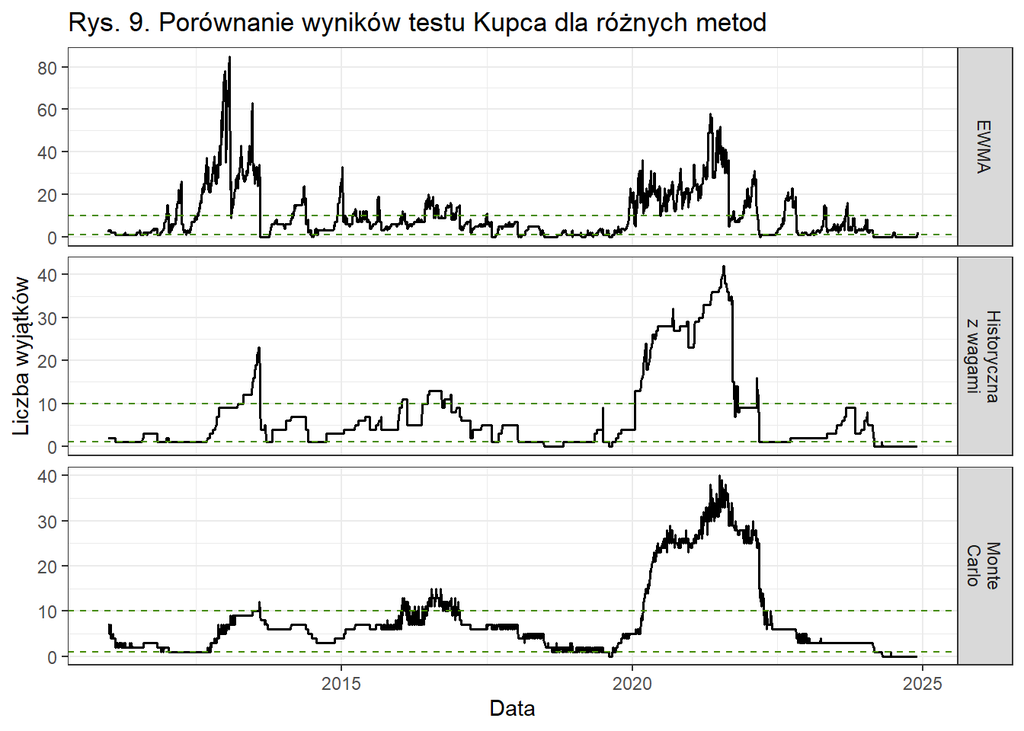

Tabela 4. Porównanie wyników testu Kupca dla różnych metod

| Metoda | Liczba wyjątków | Udział wyjątków |
| --- | --- | --- |
| Historyczna z wagami | 924 | 0.2654 |
| EWMA | 1403 | 0.4030 |
| Monte Carlo | 818 | 0.2350 |

Na powyższych wizualizacjach przedstawiono wyniki uzyskane dla testu Kupca. Z uwagi na znaczną rozbieżność wartości wyznaczanych statystyk, a w związku z tym utrudnioną interpretację, zdecydowano się na przedstawienie rezultatów testu w odniesieniu do liczby wyjątków. Obszar wydzielony poprzez zielone, przerywane linie wskazuje na występowanie przekroczeń, które mogą byc uznane za akceptowalne.

### 5.2. Test wykorzystujący rozkład dwumianowy

**Test wykorzystujący rozkład dwumianowy** opiera się na założeniu, że wystąpienie wyjątków jest niezależne. W ramach tego podejścia oblicza się prawdopodobieństwo uzyskania określonej liczby przekroczeń, które mogą wystąpić w danym zbiorze danych. Jeśli obliczone prawdopodobieństwo przekracza wartość 5%, można uznać, że zaobserwowana liczba wyjątków jest statystycznie akceptowalna i mogła wystąpić przypadkowo.

```r
# Test wykorzystujący rozkład dwumianowy (wzór Bernoulliego)
BD_test <- function(data, VaR, window_size) {

  BD_results <- data.frame(date = as.Date(character()),
                           P = numeric(),
                           num_exceptions = numeric(),
                           bad_exceptions = numeric())

  for (i in 1:(nrow(data) - window_size)) {

    window_var <- VaR[i:(i + window_size - 1)]
    if (any(is.na(window_var))) {
      next
    }

    window <- data[i:(i + window_size - 1), ]
    losses <- window$losses

    excepts <- sum(losses > VaR[i])
    p <- 1 - pbinom(excepts - 1, size = window_size, prob = 0.01)

    bad_except <- ifelse(p < 0.05, excepts, 0)

    window_date <- data$date[i + window_size - 1]
    BD_results <- rbind(BD_results, data.frame(date = window_date,
                                               P = p,
                                               num_exceptions = excepts,
                                               bad_exceptions = bad_except))
  }

  return(BD_results)
}

BD_weighted <- BD_test(mil_data[-1,], WHS_results$weighted_VaR, 500)
BD_EWMA <- BD_test(mil_data[-1,], EWMA_results$EWMA_VaR, 500)
BD_MC <- BD_test(mil_data[-1,], MC_results$MC_VaR, 500)
```

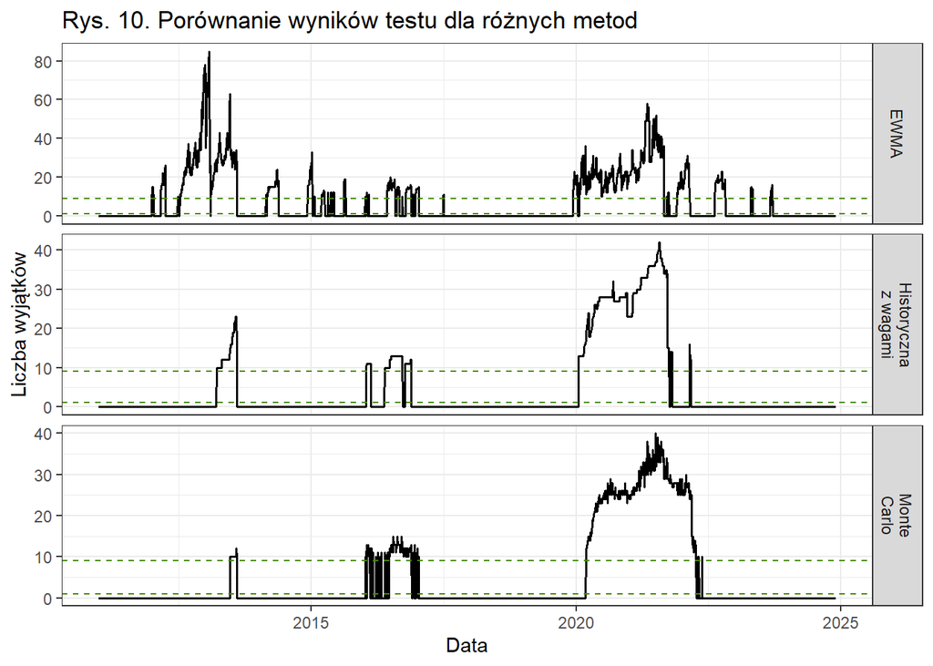

Tabela 5. Porównanie wyników testu dla różnych metod

| Metoda | Liczba wyjątków | Udział wyjątków |
| --- | --- | --- |
| Historyczna z wagami | 637 | 0.1830 |
| EWMA | 1062 | 0.3051 |
| Monte Carlo | 652 | 0.1873 |

Na podstawie wyników zaprezentowanych w tabeli 5 można stwierdzić, iż najwięcej wyjątków odnotowano w przypadku wartości VaR wyznaczonego przy zastosowaniu metody EWMA, gdzie liczba wyjątków wyniosła 1062, co stanowiło 30.51% wszystkich wartości. Z kolei najmniejszą liczbę przekroczeń tj. 637 zaobserwowano w przypadku metody symulacji historycznej uwzględniającej wagi. Warto również zwrócić uwagę na wyniki uzyskane za pomocą metody Monte Carlo, która stosunkowo skutecznie szacowała wartość ryzyka szczególnie w okresie przed rokiem 2015. W tym czasie liczba wyjątków była mniejsza niż w przypadku innych metod.

### 5.3. Test Christoffersena

**Test Christoffersena** służy do oceny, czy przekroczenia wartości narażonej na stratę występują losowo, czy też wykazują zależność w czasie. Hipoteza zerowa zakłada niezależność przekroczeń, natomiast hipoteza alternatywna wskazuje na ich skupianie się w krótkich odstępach, co może świadczyć o niedoszacowaniu ryzyka w warunkach zwiększonej zmienności rynkowej. Dla wspomnianego testu przyjmuje się następujący zestaw hipotez:

$$\begin{align*}
H_0: & \; \text{przekroczenia } VaR \text{ są niezależne w czasie}
\\
H_1: & \; \text{przekroczenia } VaR \text{ nie są niezależne w
czasie}
\end{align*}$$

```r
# Test Christoffersena
CH_test <- function(data, VaR, window_size) {

  CH_results <- data.frame(date = as.Date(character()), LR = numeric())

  for (i in 1:(nrow(data) - window_size)) {

    window_var <- VaR[i:(i + window_size - 1)]
    if (any(is.na(window_var))) {
      next
    }

    window <- data[i:(i + window_size - 1), ]
    losses <- window$losses

    m <- sum(losses > VaR[i])

    u_00 <- 0
    u_10 <- 0
    u_11 <- 0
    u_01 <- 0

    for (j in 2:(length(losses))) {
      if (losses[j] > VaR[i] & losses[j - 1] < VaR[i]) {
        u_01 <- 1 + u_01
      }
      else if (losses[j] > VaR[i] & losses[j - 1] > VaR[i]) {
        u_11 <- 1 + u_11
      }
      else if (losses[j] < VaR[i] & losses[j - 1] < VaR[i]) {
        u_00 <- 1 + u_00
      }
      else {
        u_10 <- 1 + u_10
      }
    }

    pi <- (u_01 + u_11) / (u_11 + u_00 + u_10 + u_01)
    pi_01 <- u_01 / (u_00 + u_01)
    pi_11 <- u_11 / (u_10 + u_11)

    lower <- ((1 - pi) ^ (u_00 + u_10)) * (pi ^ (u_01 + u_11))
    upper <- ((1 - pi_01) ^ (u_00)) * (pi_01 ^ (u_01)) * ((1 - pi_11) ^ u_10) * (pi_11 ^ u_11)
    lr <- 2*log(upper/lower)

    window_date <- data$date[i + window_size - 1]
    CH_results <- rbind(CH_results, data.frame(date = window_date, LR = lr))
  }

  return(CH_results)
}

CH_weighted <- CH_test(mil_data[-1,], WHS_results$weighted_VaR, 500)
CH_EWMA <- CH_test(mil_data[-1,], EWMA_results$EWMA_VaR, 500)
CH_MC <- CH_test(mil_data[-1,], MC_results$MC_VaR, 500)
```

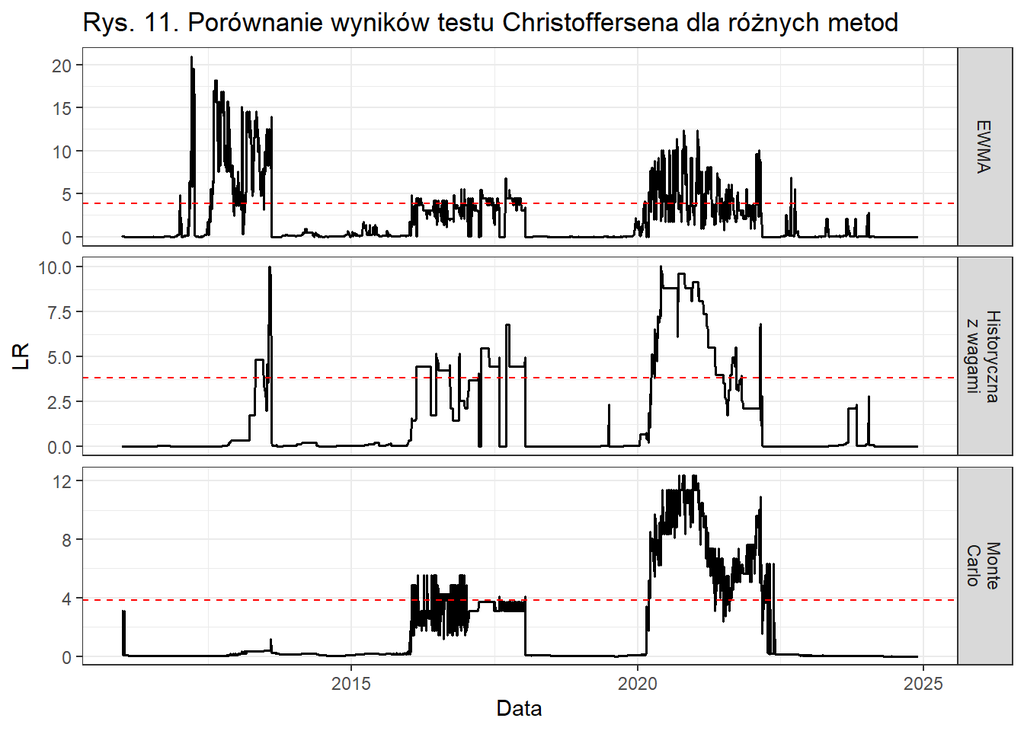

Na zamieszczonych wyżej wizualizacjach przedstawiono wyniki uzyskane na podstawie testu niezależności Christoffersena. Za pomocą czerwonej, przerywanej linii oznaczono wartość rozkładu $\small \chi^2$ o jednym stopniu swobody, odpowiadającą poziomowi istotności α = 5%, której przekroczenie wskazuje na istnienie podstaw do odrzucenia hipotezy zerowej. W przeprowadzonym teście odrzucenie $\small H_0$ jest zjawiskiem niepożądanym, gdyż wskazuje na obecność zależności w czasie, co stanowi istotną wadę metod wyznaczania wartości zagrożonej. Na wykresie można zauważyć, że okresy, w których wartość statystyki testowej przekracza poziom krytyczny, w dużej mierze pokrywają się dla wszystkich trzech metod. Aby móc dokładniej określić, która z metod częściej odrzucała hipotezę o niezależności przekroczeń VaR w czasie, dokonano odpowiedniego zestawienia, którego wyniki zostały zaprezentowane poniżej.

Tabela 6. Porównanie wyników testu Christoffersena dla różnych metod

| Metoda | Odsetek odrzuceń H0 |
| --- | --- |
| Historyczna z wagami | 0.1962 |
| EWMA | 0.1979 |
| Monte Carlo | 0.1790 |

Wyniki przedstawione w tabeli 6 wskazują, że hipoteza zerowa testu Christoffersena o niezależności przekroczeń VaR w czasie była odrzucana najczęściej w przypadku metody EWMA. Z kolei najmniejszy odsetek odrzuceń hipotezy zerowej odnotowano dla metody Monte Carlo co sugeruje, że wykazuje ona relatywnie mniejszą zależność wyjątków w czasie. Jest to pożądana cecha, która świadczy o wyższej skuteczności wspomnianego podejścia w modelowaniu ryzyka.

### 5.4. Porównanie wyników testów

W celu oceny, która z analizowanych metod testów wstecznych charakteryzowała się najlepszymi wynikami pod względem liczby wystąpień wyjątków, sporządzono zestawienie otrzymanych rezultatów zamieszczone w poniższej tabeli.

Tabela 7. Porównanie wyników testów dystrybucyjnych dla różnych metod

| Metoda | Test Kupca Liczba wyjątków | Test Kupca Udział wyjątków | Test r. dwumianowy Liczba wyjątków | Test r. dwumianowy Udział wyjątków |
| --- | --- | --- | --- | --- |
| Historyczna z wagami | 924 | 0.2654 | 637 | 0.1830 |
| EWMA | 1403 | 0.4030 | 1062 | 0.3051 |
| Monte Carlo | 818 | 0.2350 | 652 | 0.1873 |

Wyniki przedstawione w tabeli 7 wskazują, iż w przypadku testu Kupca metoda EWMA wykazuje najwyższy odsetek wyjątków wynoszący ok. 40.3%, co oznacza, że w tej metodzie występuje większa liczba przekroczeń wartości zagrożonej w porównaniu do innych technik. Z kolei najniższy odsetek wyjątków w teście odnotowano dla metody Monte Carlo, co może świadczyć o lepszej stabilności tej metody w kontekście przewidywania ryzyka. Podobne wnioski można wyciągnąć z testu rozkładu dwumianowego, gdzie również metoda EWMA odznacza się najwyższym odsetkiem wyjątków, jednakże w tym przypadku najlepsze rezultaty osiąga metoda symulacji historycznej z uwzględnieniem wag. Można zatem stwierdzić, iż metoda stosująca model EWMA poradziła sobie najgorzej w przypadku oszacowania ryzyka dla analizowanych danych. Lepsze rezultaty szacowania wartości zagrożonej uzyskano za pomocą metod symulacji historycznej z wagami oraz Monte Carlo. Warto również podkreślić, że dla metody Monte Carlo stwierdzono najmniejszy odsetek zależności wyjątków w czasie.

Dodatkowo, w celu weryfikacji rzeczywistej liczby przekroczeń wartości zagrożonej przeprowadzono test wartości rzeczywistych, którego rezultaty przedstawiono w tabeli poniżej.

```r
# Test wartości rzeczywistych
R_test <- function(data, VaR) {
  data <- data %>%
    mutate(R_results = ifelse(!is.na(losses) & !is.na(VaR) & losses > VaR, 1, 0))
  return(data)
}

R_HS <- R_test(HS_results, HS_results$VaR)
R_WHS <- R_test(WHS_results, WHS_results$weighted_VaR)
R_EWMA <- R_test(EWMA_results, EWMA_results$EWMA_VaR)
R_MC <- R_test(MC_results, MC_results$MC_VaR)
```

Tabela 8. Porównanie wyników testu wartości rzeczywistych dla różnych metod

| Metoda | Liczba wyjątków | Udział wyjątków |
| --- | --- | --- |
| Historyczna | 45 | 0.0100 |
| Historyczna z wagami | 46 | 0.0103 |
| EWMA | 46 | 0.0103 |
| Monte Carlo | 50 | 0.0112 |

Wyniki przedstawione w tabeli 8 wskazują na zbliżony poziom liczby wyjątków w przypadku większości metod, z niewielkimi różnicami między nimi. Najwięcej wyjątków wystąpiło w metodzie Monte Carlo, których udział stanowił 1.12%. Metody symulacji historycznej, symulacji historycznej z wagami oraz EWMA wykazały bardzo zbliżone wartości, z udziałem wyjątków mieszczących się w granicach 1-1.03%.